# Introduction and Workflow

### Adapted from code by Ken Benoit

This file demonstrates a basic workflow to take some pre-loaded texts and perform elementary text analysis tasks quickly. The `quanteda` packages comes with a built-in set of inaugural addresses from US Presidents. We begin by loading quanteda and examining these texts. The `summary` command will output the name of each text along with the number of types, tokens and sentences contained in the text. Below we use R’s indexing syntax to selectivly use the summary command on the first five texts.

```r
require(quanteda)
summary(data_corpus_inaugural)
## Corpus consisting of 58 documents:
##
##             Text Types Tokens Sentences Year  President       FirstName
##  1789-Washington   625   1538        23 1789 Washington          George
##  1793-Washington    96    147         4 1793 Washington          George
##       1797-Adams   826   2578        37 1797      Adams            John
##   1801-Jefferson   717   1927        41 1801  Jefferson          Thomas
##   1805-Jefferson   804   2381        45 1805  Jefferson          Thomas
##     1809-Madison   535   1263        21 1809    Madison           James
##     1813-Madison   541   1302        33 1813    Madison           James
##      1817-Monroe  1040   3680       121 1817     Monroe           James
##      1821-Monroe  1259   4886       129 1821     Monroe           James
##       1825-Adams  1003   3152        74 1825      Adams     John Quincy
##     1829-Jackson   517   1210        25 1829    Jackson          Andrew
##     1833-Jackson   499   1269        29 1833    Jackson          Andrew
##    1837-VanBuren  1315   4165        95 1837  Van Buren          Martin
##    1841-Harrison  1896   9144       210 1841   Harrison   William Henry
##        1845-Polk  1334   5193       153 1845       Polk      James Knox
##      1849-Taylor   496   1179        22 1849     Taylor         Zachary
##      1853-Pierce  1165   3641       104 1853     Pierce        Franklin
##    1857-Buchanan   945   3086        89 1857   Buchanan           James
##     1861-Lincoln  1075   4006       135 1861    Lincoln         Abraham
##     1865-Lincoln   360    776        26 1865    Lincoln         Abraham
##       1869-Grant   485   1235        40 1869      Grant      Ulysses S.
##       1873-Grant   552   1475        43 1873      Grant      Ulysses S.
##       1877-Hayes   831   2716        59 1877      Hayes   Rutherford B.
##    1881-Garfield  1021   3212       111 1881   Garfield        James A.
##   1885-Cleveland   676   1820        44 1885  Cleveland          Grover
##    1889-Harrison  1352   4722       157 1889   Harrison        Benjamin
##   1893-Cleveland   821   2125        58 1893  Cleveland          Grover
##    1897-McKinley  1232   4361       130 1897   McKinley         William
##    1901-McKinley   854   2437       100 1901   McKinley         William
##   1905-Roosevelt   404   1079        33 1905  Roosevelt        Theodore
##        1909-Taft  1437   5822       159 1909       Taft  William Howard
##      1913-Wilson   658   1882        68 1913     Wilson         Woodrow
##      1917-Wilson   549   1656        59 1917     Wilson         Woodrow
##     1921-Harding  1169   3721       148 1921    Harding       Warren G.
##    1925-Coolidge  1220   4440       196 1925   Coolidge          Calvin
##      1929-Hoover  1090   3865       158 1929     Hoover         Herbert
##   1933-Roosevelt   743   2062        85 1933  Roosevelt     Franklin D.
##   1937-Roosevelt   725   1997        96 1937  Roosevelt     Franklin D.
##   1941-Roosevelt   526   1544        68 1941  Roosevelt     Franklin D.
##   1945-Roosevelt   275    647        26 1945  Roosevelt     Franklin D.
##      1949-Truman   781   2513       116 1949     Truman        Harry S.
##  1953-Eisenhower   900   2757       119 1953 Eisenhower       Dwight D.
##  1957-Eisenhower   621   1931        92 1957 Eisenhower       Dwight D.
##     1961-Kennedy   566   1566        52 1961    Kennedy         John F.
##     1965-Johnson   568   1723        93 1965    Johnson   Lyndon Baines
##       1969-Nixon   743   2437       103 1969      Nixon Richard Milhous
##       1973-Nixon   544   2012        68 1973      Nixon Richard Milhous
##      1977-Carter   527   1376        52 1977     Carter           Jimmy
##      1981-Reagan   902   2790       128 1981     Reagan          Ronald
##      1985-Reagan   925   2921       123 1985     Reagan          Ronald
##        1989-Bush   795   2681       141 1989       Bush          George
##     1993-Clinton   642   1833        81 1993    Clinton            Bill
##     1997-Clinton   773   2449       111 1997    Clinton            Bill
##        2001-Bush   621   1808        97 2001       Bush       George W.
##        2005-Bush   773   2319       100 2005       Bush       George W.
##       2009-Obama   938   2711       110 2009      Obama          Barack
##       2013-Obama   814   2317        88 2013      Obama          Barack
##       2017-Trump   582   1660        88 2017      Trump       Donald J.
##
## Source: Gerhard Peters and John T. Woolley. The American Presidency Project.
## Created: Tue Jun 13 14:51:47 2017
## Notes: http://www.presidency.ucsb.edu/inaugurals.php
summary(data_corpus_inaugural[1:5])
```

```
##    Length     Class      Mode
##         5 character character
```

```r
data_corpus_inaugural[1]
```

```
##                                                                                                                                                                                                                                                                                                          …
## "Fellow-Citizens of the Senate and of the House of Representatives:\n\nAmong the vicissitudes incident to life no event could have filled me with greater anxieties than that of which the notification was transmitted by your order, and received on the 14th day of the present month. On the one hand…
```

```r
cat(data_corpus_inaugural[2])
## Fellow citizens, I am again called upon by the voice of my country to execute the functions of its Chief Magistrate. When the occasion proper for it shall arrive, I shall endeavor to express the high sense I entertain of this distinguished honor, and of the confidence which has been reposed in me by the people of united America.
##
## Previous to the execution of any official act of the President the Constitution requires an oath of office. This oath I am now about to take, and in your presence: That if it shall be found during my administration of the Government I have in any instance violated willingly or knowingly the injunctions thereof, I may (besides incurring constitutional punishment) be subject to the upbraidings of all who are now witnesses of the present solemn ceremony.
##
##

ndoc(data_corpus_inaugural)
```

```
## [1] 58
```

```r
docnames(data_corpus_inaugural)
```

```
##  [1] "1789-Washington" "1793-Washington" "1797-Adams"
##  [4] "1801-Jefferson"  "1805-Jefferson"  "1809-Madison"
##  [7] "1813-Madison"    "1817-Monroe"     "1821-Monroe"
## [10] "1825-Adams"      "1829-Jackson"    "1833-Jackson"
## [13] "1837-VanBuren"   "1841-Harrison"   "1845-Polk"
## [16] "1849-Taylor"     "1853-Pierce"     "1857-Buchanan"
## [19] "1861-Lincoln"    "1865-Lincoln"    "1869-Grant"
## [22] "1873-Grant"      "1877-Hayes"      "1881-Garfield"
## [25] "1885-Cleveland"  "1889-Harrison"   "1893-Cleveland"
## [28] "1897-McKinley"   "1901-McKinley"   "1905-Roosevelt"
## [31] "1909-Taft"       "1913-Wilson"     "1917-Wilson"
## [34] "1921-Harding"    "1925-Coolidge"   "1929-Hoover"
## [37] "1933-Roosevelt"  "1937-Roosevelt"  "1941-Roosevelt"
## [40] "1945-Roosevelt"  "1949-Truman"     "1953-Eisenhower"
## [43] "1957-Eisenhower" "1961-Kennedy"    "1965-Johnson"
## [46] "1969-Nixon"      "1973-Nixon"      "1977-Carter"
## [49] "1981-Reagan"     "1985-Reagan"     "1989-Bush"
## [52] "1993-Clinton"    "1997-Clinton"    "2001-Bush"
## [55] "2005-Bush"       "2009-Obama"      "2013-Obama"
## [58] "2017-Trump"
```

```r
nchar(data_corpus_inaugural[1:7])
## 1789-Washington 1793-Washington      1797-Adams  1801-Jefferson
##            8618             790           13876           10136
##  1805-Jefferson    1809-Madison    1813-Madison
##           12907            7000            7156
ntoken(data_corpus_inaugural[1:7])
## 1789-Washington 1793-Washington      1797-Adams  1801-Jefferson
##            1538             147            2578            1927
##  1805-Jefferson    1809-Madison    1813-Madison
##            2381            1263            1302
ntoken(data_corpus_inaugural[1:7], remove_punct = TRUE)
## 1789-Washington 1793-Washington      1797-Adams  1801-Jefferson
##            1430             135            2318            1726
##  1805-Jefferson    1809-Madison    1813-Madison
##            2166            1175            1210
ntype(data_corpus_inaugural[1:7])
## 1789-Washington 1793-Washington      1797-Adams  1801-Jefferson
##             625              96             826             717
##  1805-Jefferson    1809-Madison    1813-Madison
##             804             535             541
```

One of the most fundamental text analysis tasks is tokenization. To tokenize a text is to split it into units, most commonly words, which can be counted and to form the basis of a quantitative analysis. The quanteda package has a function for tokenization: `tokens`, which constructs a **quanteda** tokens object consisting of the texts segmented by their terms (and by default, other elements such as punctuation, numbers, symbols, etc.). Examine the manual page at `?tokens` for this details about this function:

```r
?tokens
```

**quanteda**’s `tokens` function can be used on a simple character vector, a vector of character vectors, or a corpus. Here are some examples:

```r
tokens("Today is Thursday in Canberra. It is yesterday in London.")
## tokens from 1 document.
## text1 :
##  [1] "Today"     "is"        "Thursday"  "in"        "Canberra"
##  [6] "."         "It"        "is"        "yesterday" "in"
## [11] "London"    "."

vec <- c(one = "This is text one",
         two = "This, however, is the second text")
tokens(vec)
## tokens from 2 documents.
## one :
## [1] "This" "is"   "text" "one"
##
## two :
## [1] "This"    ","       "however" ","       "is"      "the"     "second"
## [8] "text"
```

Consider the default arguments to the `tokens()` function. To remove punctuation, you should set the `remove_punct` argument to be `TRUE`. We can combine this with the `char_tolower()` function to get a cleaned and tokenized version of our text.

```r
tokens(char_tolower(vec), remove_punct = TRUE)
## tokens from 2 documents.
## one :
## [1] "this" "is"   "text" "one"
##
## two :
## [1] "this"    "however" "is"      "the"     "second"  "text"
```

The way that `char_tolower()` is named reflects the [logic of **quanteda**’s function grammar](http://quanteda.io/articles/pkgdown_only/design.html). The first part (before the underscore `_`) names the both class of object that is input to the function and is returned by the function. To lowercase an R `character` class object, for instance, you use `char_tolower()`, and to lowercase a **quanteda** `tokens` class object, you use `tokens_tolower()`. Some object classes are defined in base R, and some have been defined by packages that extend R’s functionality (**quanteda** is one example – there are [well over 10,000 contributed packages](https://cran.r-project.org/web/packages/) on the CRAN archive alone. CRAN stands for Comprehensive R Archive Network and is where the **quanteda** package is published.)

Using this function with the inaugural addresses:

```r
inaugTokens <- tokens(data_corpus_inaugural, remove_punct = TRUE)
tokens_tolower(inaugTokens[2])
## tokens from 1 document.
## 1793-Washington :
##   [1] "fellow"         "citizens"       "i"              "am"
##   [5] "again"          "called"         "upon"           "by"
##   [9] "the"            "voice"          "of"             "my"
##  [13] "country"        "to"             "execute"        "the"
##  [17] "functions"      "of"             "its"            "chief"
##  [21] "magistrate"     "when"           "the"            "occasion"
##  [25] "proper"         "for"            "it"             "shall"
##  [29] "arrive"         "i"              "shall"          "endeavor"
##  [33] "to"             "express"        "the"            "high"
##  [37] "sense"          "i"              "entertain"      "of"
##  [41] "this"           "distinguished"  "honor"          "and"
##  [45] "of"             "the"            "confidence"     "which"
##  [49] "has"            "been"           "reposed"        "in"
##  [53] "me"             "by"             "the"            "people"
##  [57] "of"             "united"         "america"        "previous"
##  [61] "to"             "the"            "execution"      "of"
##  [65] "any"            "official"       "act"            "of"
##  [69] "the"            "president"      "the"            "constitution"
##  [73] "requires"       "an"             "oath"           "of"
##  [77] "office"         "this"           "oath"           "i"
##  [81] "am"             "now"            "about"          "to"
##  [85] "take"           "and"            "in"             "your"
##  [89] "presence"       "that"           "if"             "it"
##  [93] "shall"          "be"             "found"          "during"
##  [97] "my"             "administration" "of"             "the"
## [101] "government"     "i"              "have"           "in"
## [105] "any"            "instance"       "violated"       "willingly"
## [109] "or"             "knowingly"      "the"            "injunctions"
## [113] "thereof"        "i"              "may"            "besides"
## [117] "incurring"      "constitutional" "punishment"     "be"
## [121] "subject"        "to"             "the"            "upbraidings"
## [125] "of"             "all"            "who"            "are"
## [129] "now"            "witnesses"      "of"             "the"
## [133] "present"        "solemn"         "ceremony"
```

Here, we supplied one of the optional *arguments* to the `tokens()` function: `remove_punct`. This functon takes a [“logical” type value](https://stat.ethz.ch/R-manual/R-devel/library/base/html/logical.html) (`TRUE` or `FALSE`) and specifies whether punctuation characters should be removed or not. The help page for `tokens()`, which you can access using the command `?tokens`, details all of the function arguments and their valid values.

Every function in R and its contributed packages has a help page, and this is the first place to look when examining a function. Well-written help pages will also contain examples that you can run to see how a function operates. For **quanteda**, the main functions also have help pages with the results of executing their examples on http://quanteda.io/reference/.

Returning to tokenization: Once each text has been split into words, we can use the `dfm` function to create a matrix of counts of the occurrences of each word in each document:

```r
inaugDfm <- dfm(inaugTokens)
trimmedInaugDfm <- dfm_trim(inaugDfm, min_doc = 5, min_count = 10)
weightedTrimmedDfm <- dfm_tfidf(trimmedInaugDfm)

require(magrittr)
inaugDfm2 <- dfm(inaugTokens) %>%
    dfm_trim(min_doc = 5, min_count = 10) %>%
        dfm_tfidf()
```

Note that `dfm()` works on a variety of object types, including character vectors, corpus objects, and tokenized text objects. This gives the user maximum flexibility and power, while also making it easy to achieve similar results by going directly from texts to a document-by-feature matrix.

To see what objects for which any particular *method* (function) is defined, you can use the `methods()` function:

```r
methods(dfm)
```

```
## [1] dfm.character* dfm.corpus*    dfm.default*   dfm.dfm*
## [5] dfm.tokens*
## see '?methods' for accessing help and source code
```

Likewise, you can also figure out what methods are defined for any given *class* of object, using the same function:

```r
methods(class = "tokens")
```

```
##  [1] $                     [                     [[
##  [4] [[<-                  [<-                   +
##  [7] as.character          as.list               c
## [10] dfm                   docnames              docnames<-
## [13] docvars               docvars<-             fcm
## [16] kwic                  lengths               metadoc
## [19] ndoc                  nsentence             nsyllable
## [22] ntoken                ntype                 phrase
## [25] print                 textstat_collocations tokens
## [28] tokens_compound       tokens_lookup         tokens_ngrams
## [31] tokens_replace        tokens_segment        tokens_select
## [34] tokens_skipgrams      tokens_subset         tokens_tolower
## [37] tokens_toupper        tokens_wordstem       types
## [40] unlist
## see '?methods' for accessing help and source code
```

```r
summary(data_corpus_inaugural[52:57])
```

```
##    Length     Class      Mode
##         6 character character
```

We can use the `docvars` option to the `corpus` command to record the party with which each text is associated:

```r
dv <- data.frame(Party = c("dem", "dem", "rep", "rep", "dem", "dem"))
recentCorpus <- corpus(data_corpus_inaugural[52:57], docvars = dv)
summary(recentCorpus)
## Corpus consisting of 6 documents:
##
##          Text Types Tokens Sentences Party
##  1993-Clinton   642   1833        81   dem
##  1997-Clinton   773   2449       111   dem
##     2001-Bush   621   1808        97   rep
##     2005-Bush   773   2319       100   rep
##    2009-Obama   938   2711       110   dem
##    2013-Obama   814   2317        88   dem
##
## Source: C:/Users/kevin/Documents/GitHub/Intro_Data_Science_Rosario/code/intro_text_as_data/* on x86-64 by kevin
## Created: Tue May 22 16:21:30 2018
## Notes:
```

We can use this metadata to combine features across documents when creating a document-feature matrix:

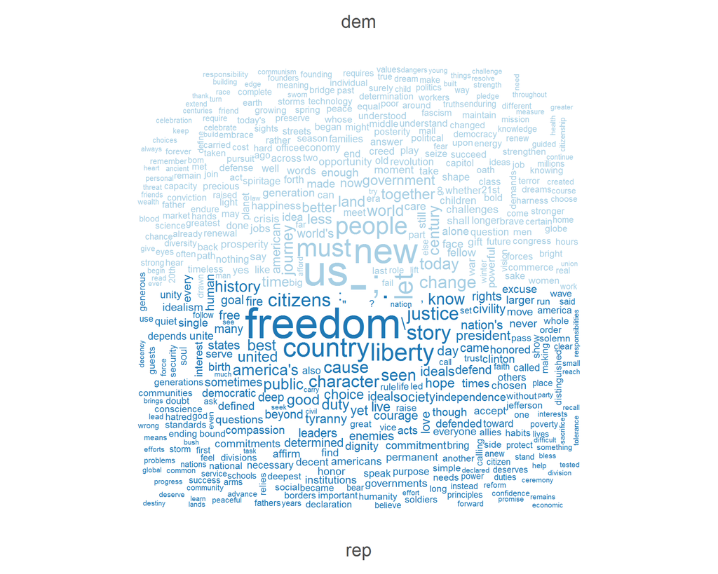

```r
partyDfm <- dfm(recentCorpus, groups = "Party", remove = (stopwords("english")))
textplot_wordcloud(partyDfm, comparison = TRUE)
```